# Analyzing Global Air Emissions

Final Project  
Data Science 1 with R (STAT 301-1)

Author

Chiemela Onuoha

Published

December 4, 2024

**Github Repo Link**

[Chiemela Onuoha’s Github (chiemelaonu)](https://github.com/stat301-1-2024-fall/final-project-1-chiemelaonu.git)

# Introduction

I chose this data because I have a genuine interest in the environment and air pollution. Climate change appears in the media more frequently, so dissecting a dataset with the emissions from different countries across different years is relevant. Besides the increase in climate change media, it is beneficial to be interested in the things around you without it being thrown in your face by the news or social media, so I intend to learn something new about the world’s yearly emissions. The data has many observations and interesting subtopics, such as the types of activities that are presumed to be causing the emissions, and I believe it would be intriguing to look into those activities, as well as how the data changes across different years or even quarters. So, questions like: Which countries have the highest emissions per quarter? Which years had the most observations? Which quarters had the most observations? Is there a disparity in air emissions among different parts of the world? i.e. the Western world vs. other parts, etc. With some relatively simple tidying of the data, I can begin to look at patterns or even discrepancies that better allow me to understand and visualize the data.

# Data Overview and Quality

```
Rows: 104,554
Columns: 11
$ `Reference area`     <chr> "Greece", "Greece", "Greece", "Greece", "Greece",…
$ EMISSIONS            <chr> "13637.64", "19243.66", "5369.33", "9962.11", "55…
$ `Observation status` <chr> NA, NA, NA, NA, NA, NA, NA, "Estimated value", NA…
$ UNIT_MEASURE         <chr> "T", "T", "T", "T", "T", "T", "T", "T", "T_CO2E",…
$ POLLUTANT            <chr> "CO2", "CO2", "CO2", "CO2", "CO2", "CO2", "CO2", …
$ TIME_PERIOD          <chr> "2015", "2016", "2017", "2018", "2019", "2020", "…
$ FREQ                 <chr> "A", "A", "A", "A", "A", "A", "A", "A", "A", "A",…
$ `Economic activity`  <chr> "Manufacture of wood and of products of wood and …
$ ACTIVITY_SCOPE       <chr> "RES", "RES", "RES", "RES", "RES", "RES", "RES", …
$ SOURCE               <chr> "REPORTED", "REPORTED", "REPORTED", "REPORTED", "…
$ Region               <chr> "Europe", "Europe", "Europe", "Europe", "Europe",…
```

Here lists the column names and the type of each column. Some of the observations for the columns are listed as well. There are 11 variables in this dataset and all of them are character variables. There are around 104,000 observations in this dataset. All of the observations are unique. I will be adding context in the README and also within my analyses when needed for columns that are not clear enough in what they represent. There are missing values in the Observation Status column, but I do not intend to do any EDA with that column, so there shouldn’t be any issues from it. In the SOURCE column, it shows that most of the data was reported by a “national statistical authority”. The methods are not highlighted, which could mean the data is not the best for accurate and definitive conclusions.

# Snippet of Dataset

Table 1: First Six Observations of Dataset

| Reference area | EMISSIONS | Observation status | UNIT_MEASURE | POLLUTANT | TIME_PERIOD | FREQ | Economic activity | ACTIVITY_SCOPE | SOURCE | Region |
| --- | --- | --- | --- | --- | --- | --- | --- | --- | --- | --- |
| Greece | 13637.64 | NA | T | CO2 | 2015 | A | Manufacture of wood and of products of wood and cork, except furniture; manufacture of articles of straw and plaiting materials | RES | REPORTED | Europe |
| Greece | 19243.66 | NA | T | CO2 | 2016 | A | Manufacture of wood and of products of wood and cork, except furniture; manufacture of articles of straw and plaiting materials | RES | REPORTED | Europe |
| Greece | 5369.33 | NA | T | CO2 | 2017 | A | Manufacture of wood and of products of wood and cork, except furniture; manufacture of articles of straw and plaiting materials | RES | REPORTED | Europe |
| Greece | 9962.11 | NA | T | CO2 | 2018 | A | Manufacture of wood and of products of wood and cork, except furniture; manufacture of articles of straw and plaiting materials | RES | REPORTED | Europe |
| Greece | 5589.8 | NA | T | CO2 | 2019 | A | Manufacture of wood and of products of wood and cork, except furniture; manufacture of articles of straw and plaiting materials | RES | REPORTED | Europe |
| Greece | 6857.83 | NA | T | CO2 | 2020 | A | Manufacture of wood and of products of wood and cork, except furniture; manufacture of articles of straw and plaiting materials | RES | REPORTED | Europe |

In this snippet of the data, you can see the columns that I left included in the data and the arrangement of the columns. Additionally, I pivoted the data so that the emissions column is called “EMISSIONS” and it holds the emissions values.

# Univariate Analysis

## Distinct Reference Areas

| Reference area |
| --- |
| Greece |
| Belgium |
| Lithuania |
| European Union (27 countries from 01/02/2020) |
| Croatia |
| Hungary |
| Bulgaria |
| Denmark |
| Portugal |
| Finland |
| Malta |
| Austria |
| Cyprus |
| Costa Rica |
| Luxembourg |
| New Zealand |
| Italy |
| United States |
| Switzerland |
| Ireland |
| Netherlands |
| Romania |
| Poland |
| Norway |
| United Kingdom |
| Estonia |
| Iceland |
| France |
| Sweden |
| Slovenia |
| Australia |
| Slovak Republic |
| Türkiye |
| Latvia |
| Germany |
| Serbia |
| Czechia |
| OECD |
| Spain |
| Colombia |
| Canada |
| Ukraine |
| Indonesia |
| Japan |
| Kazakhstan |
| Russia |
| Korea |
| Mexico |

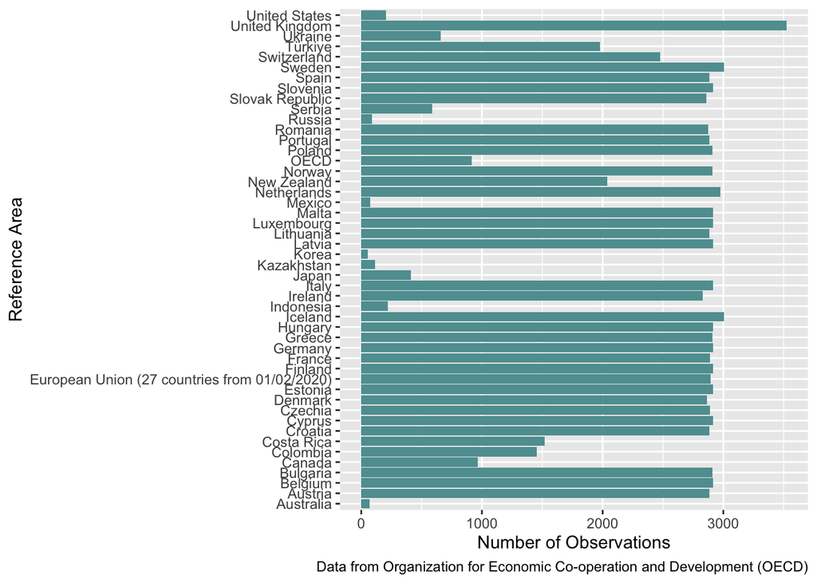

## Number of Observations for Each Year

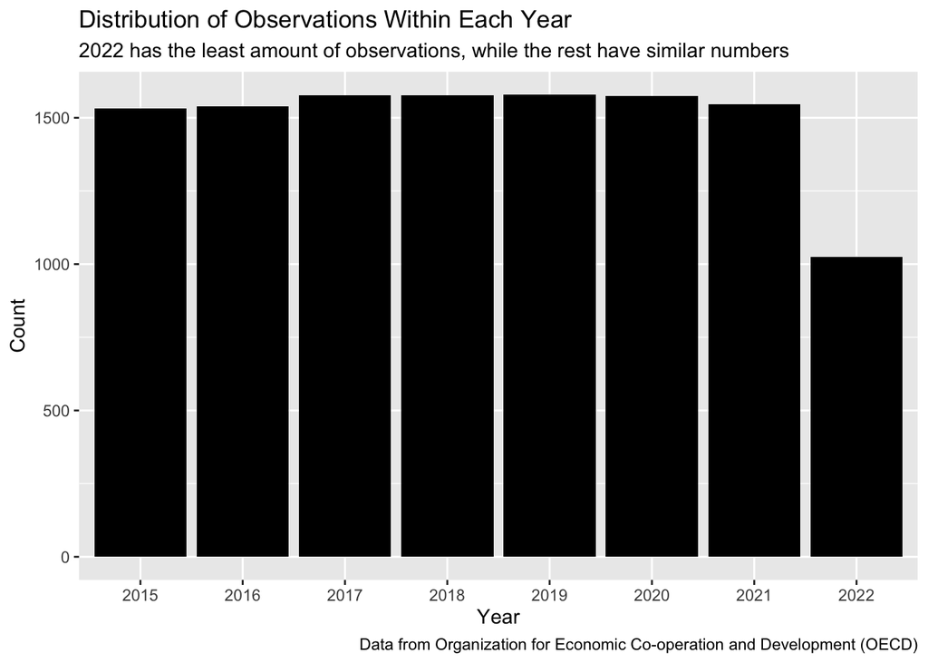

The bar chart above shows the full-year time period range of the dataset (2015-2022). The quarterly data I joined into that data goes up to 2024.

## Distribution of Pollutants

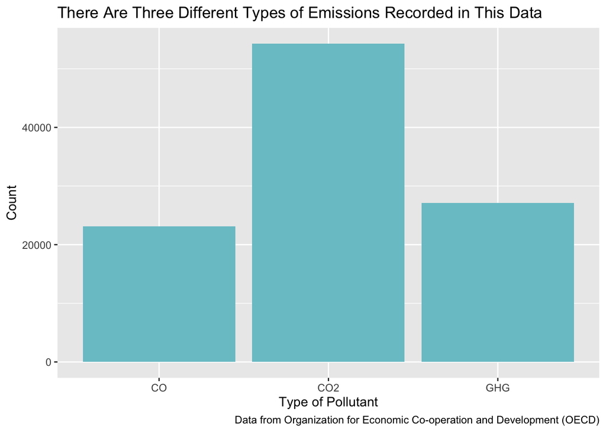

The bar graph above shows the different types of emissions recorded in this data. The types of emissions present are Carbon Monoxide (CO), Carbon Dioxide (CO2), and Greenhouse Gases (GHG). Greenhouse Gases in this data excludes carbon dioxide from biomass used as a fuel.

## Five Highest Emissions Observations

Table 2: Top Five Quarterly Emissions Observations

| Reference area | EMISSIONS | Observation status | UNIT_MEASURE | POLLUTANT | TIME_PERIOD | FREQ | Economic activity | ACTIVITY_SCOPE | SOURCE | Region |
| --- | --- | --- | --- | --- | --- | --- | --- | --- | --- | --- |
| United Kingdom | c(99719400, 104608900) | NA | T_CO2E | GHG | 2018-Q2 | Q | All ISIC activities | RES | ESTIMATED | Europe |
| United Kingdom | c(98975500, 104708800) | NA | T_CO2E | GHG | 2018-Q3 | Q | All ISIC activities | RES | ESTIMATED | Europe |
| United Kingdom | c(98108700, 93960900) | NA | T_CO2E | GHG | 2021-Q4 | Q | All ISIC activities | RES | ESTIMATED | Europe |
| United Kingdom | c(98008400, 103087500) | NA | T_CO2E | GHG | 2017-Q2 | Q | All ISIC activities | RES | ESTIMATED | Europe |
| United Kingdom | c(97740200, 93888500) | NA | T_CO2E | GHG | 2022-Q4 | Q | All ISIC activities | RES | ESTIMATED | Europe |

# Multivariate Analysis

## Plot of Emissions for Each Year by Pollutant and Unit Measure

[figure not shown]

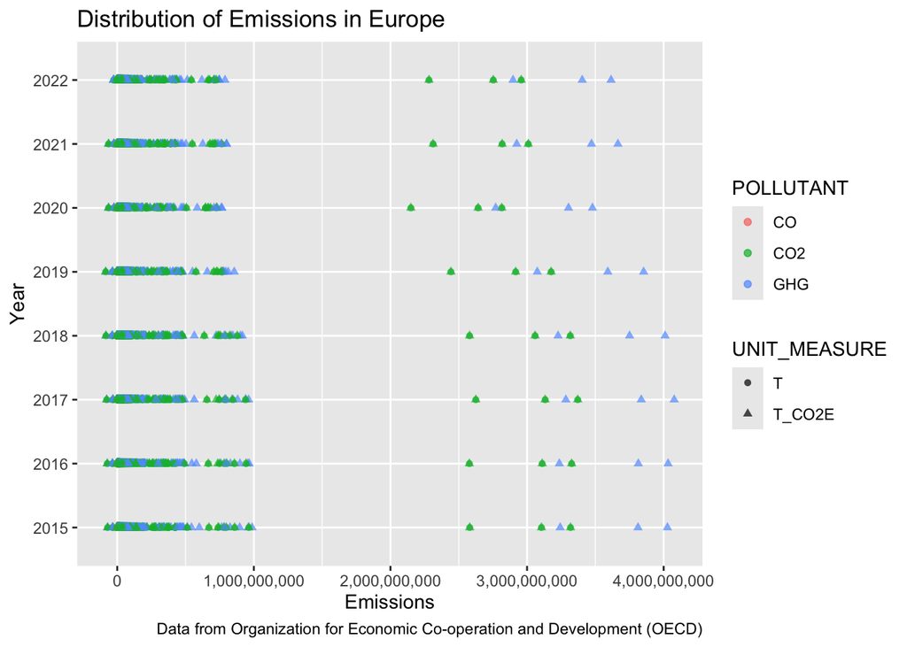

[figure not shown]

[figure not shown]

For North America, emissions are almost entirely carbon dioxide, with one observation being carbon monoxide and a few being greenhouse gases. Europe’s emissions are only carbon dioxide and greenhouse gases. This is on par with previous general beliefs because carbon monoxide emissions occur less since it is the result of incomplete combustion of fuel.[^1] This incomplete combustion occurs most often from cars, but can also occur from gas heaters or chimneys. Cars more often emit carbon dioxide as well as a plethora of other things, such as heating, electricity, and agriculture.[^2] There is a substantial amount of emissions of greenhouse gases, which are defined as gases that trap heat in the atmosphere. They can include carbon dioxide, but also Methane, Nitrous oxide, and Fluorinated gases like chlorofluorocarbons, hydrochlorofluorocarbons, etc.[^3]

<sup>1</sup> [Basic Information about Carbon Monoxide (CO) Outdoor Air Pollution](https://www.epa.gov/co-pollution/basic-information-about-carbon-monoxide-co-outdoor-air-pollution) accessed December 4th 2024

<sup>2</sup> [Sources of Greenhouse Gas Emissions](https://www.epa.gov/ghgemissions/sources-greenhouse-gas-emissions) accessed December 4th 2024

<sup>3</sup> [Overview of Greenhouse Gases](https://www.epa.gov/ghgemissions/overview-greenhouse-gases) accessed December 4th 2024

## Economic Activity

Table 3: Number of Distinct Economic Activities Recorded

| n |
| --- |
| 107 |

Table 4: Top Ten Frequently Recorded Economic Activities with Region Makeup

| Economic activity | n | Regions |
| --- | --- | --- |
| All ISIC activities and activities of households | 12556 | Asia (778), Europe (11607), North America (45), South America (43), NA (83) |
| All ISIC activities | 1651 | Asia (98), Europe (1281), North America (101), South America (88), NA (83) |
| Agriculture, forestry and fishing | 1282 | Asia (89), Europe (1022), North America (45), South America (43), NA (83) |
| Electricity, gas, steam and air conditioning supply | 1282 | Asia (89), Europe (1022), North America (45), South America (43), NA (83) |
| Mining and quarrying | 1282 | Asia (89), Europe (1022), North America (45), South America (43), NA (83) |
| Activities by households | 1281 | Asia (88), Europe (1022), North America (45), South America (43), NA (83) |
| Transportation and storage | 1281 | Asia (88), Europe (1022), North America (45), South America (43), NA (83) |
| Manufacturing | 1276 | Asia (89), Europe (1016), North America (45), South America (43), NA (83) |
| Construction | 1274 | Asia (89), Europe (1022), North America (37), South America (43), NA (83) |
| Water supply; sewerage, waste management and remediation activities | 1241 | Asia (72), Europe (1022), North America (21), South America (43), NA (83) |

<sup>4</sup> Disregard the first 2 rows because all the activities listed technically fall under “ISIC activities”

## How Do Emissions Totals Differ By Year?

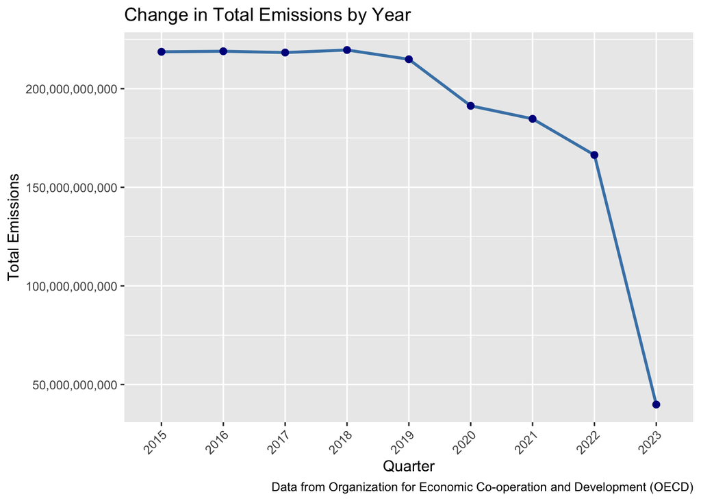

## By Quarter?

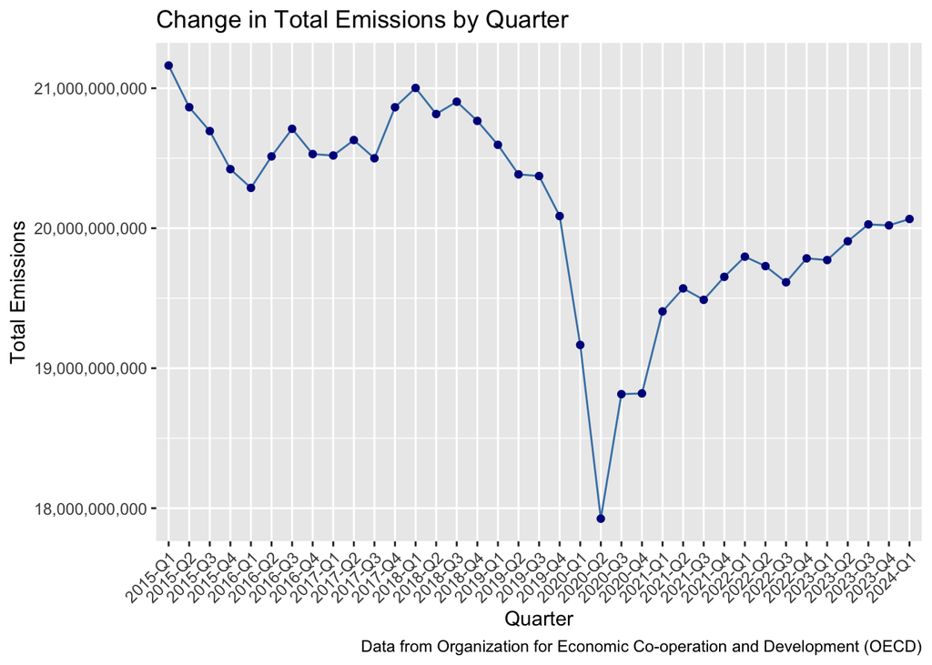

The total emissions counts by quarter fluctuate quite a bit, reaching its highest point of just over 21 billion tons in the first quarter of 2015, and its lowest point of under 18 billion tons in the second quarter of 2020. That drop in emissions counts may have something to do with the Covid-19 lockdown at that time.

## How Do Yearly Emissions Totals Differ Between Countries?

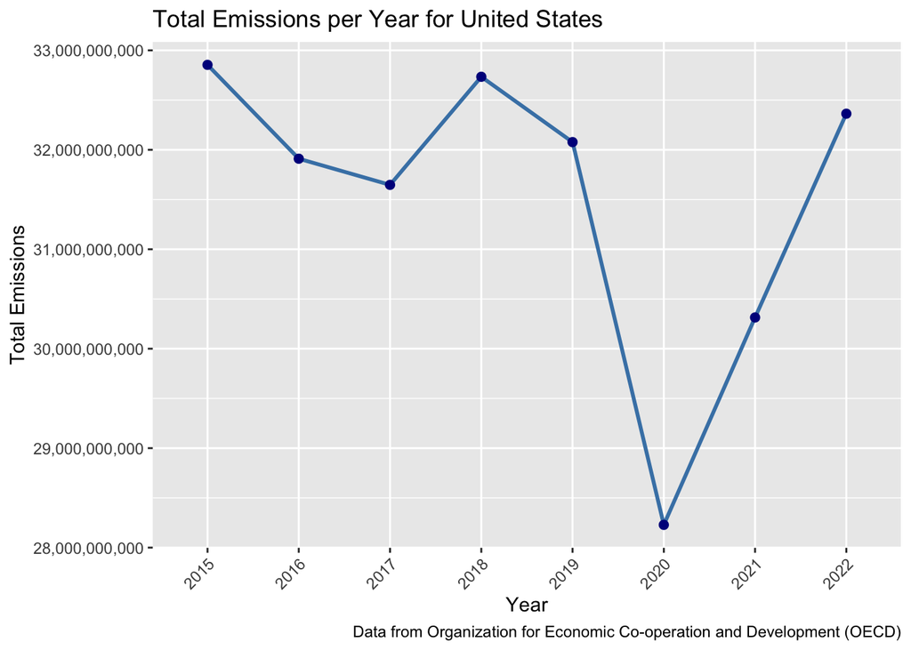

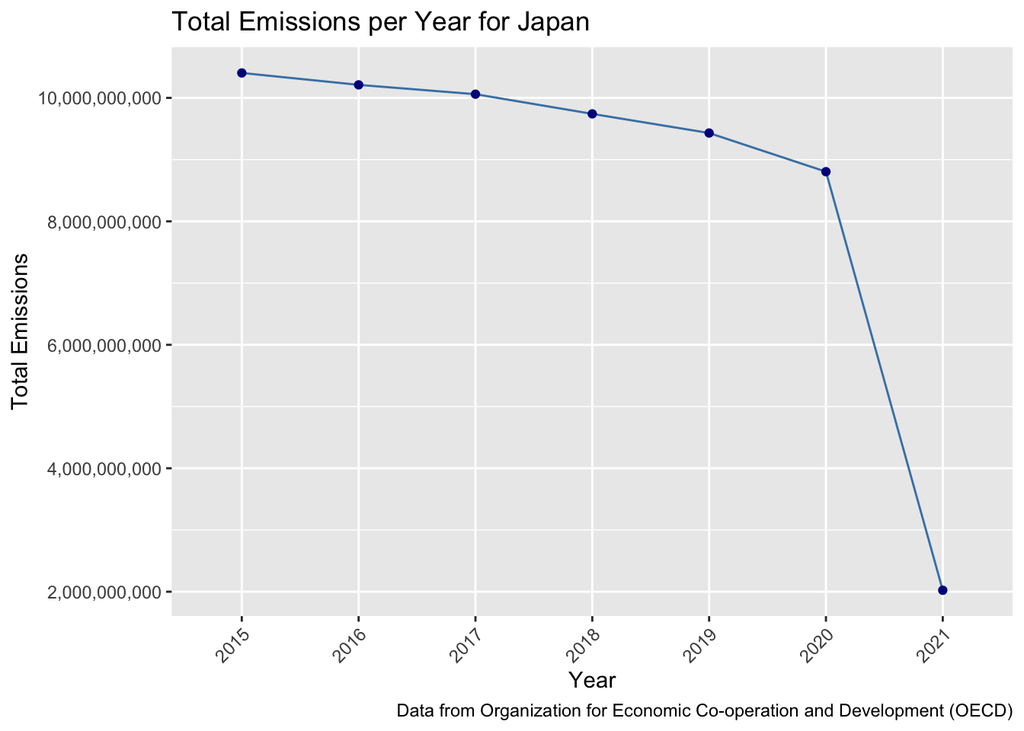

Yearly emission totals for the US started at almost 33 billion tons in 2015 and reached its lowest in 2020 at almost 28 billion tons. For Japan, emissions totals started at about 10.5 billion tons in 2015 and reached its lowest of 2 billion tons in 2021. There is a steeper decrease in emissions for Japan from 2019 to 2020, though it is not as substantial as the decrease for the US. Japan’s from 2020 to 2021 is significant though, going from 9 billion tons to 2 billion tons, whereas the emissions for the US actually increased between 2020 and 2021.

## By Region?

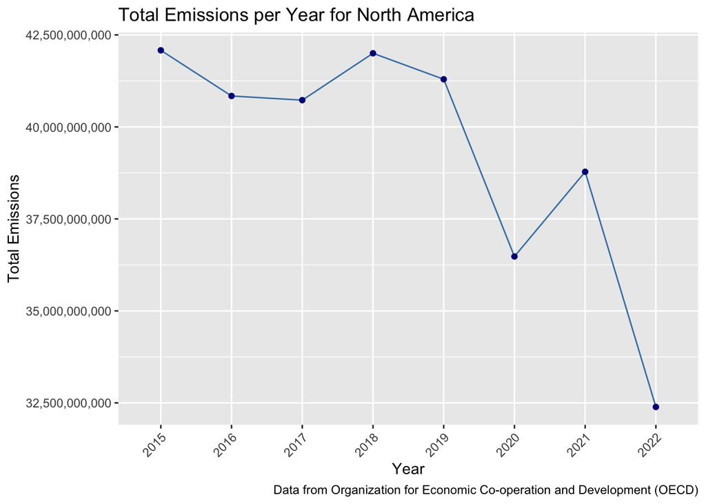

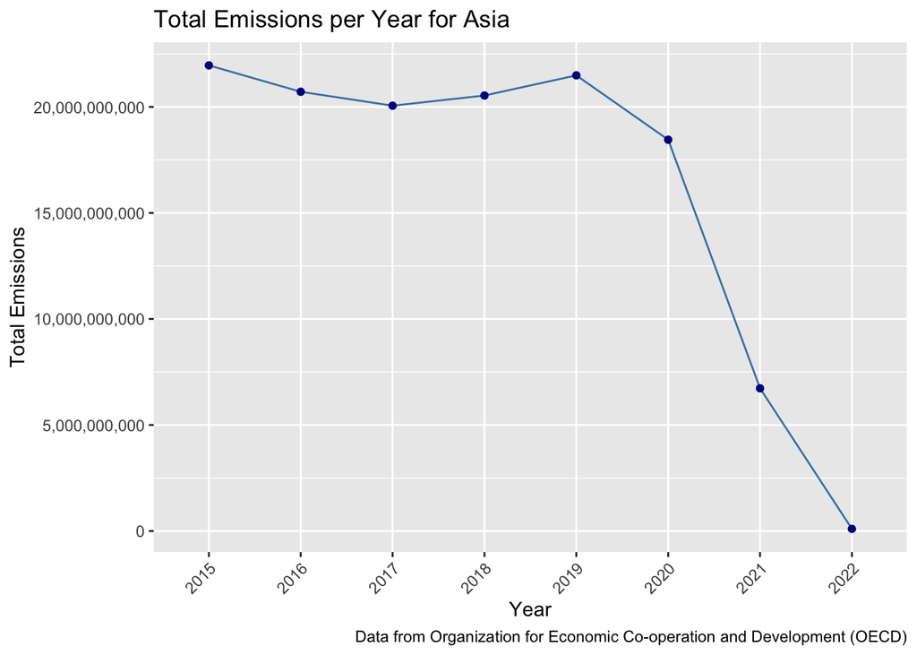

[figure not shown]

# Conclusion

This data is a great first step in looking into global emissions and trying to take note of certain yearly patterns or patterns by regions, or by country. The data has many observations but after doing the cleaning necessary for the data, there are not many columns to make truly insightful conclusions from. The work I did here with this data is primarily surface level and mostly what I could do with my expertise level. The data gave me information that I have previously known through structured learning in environmental science classes, (the western world contributes a large amount to global emissions) as well as general knowledge about the environment from the news about our air emissions tendencies. What surprised me the most would be the changes in global emissions patterns by year and by quarter and within some countries. What also surprised me was how the United Kingdom was the highest emitter by quarter. I would certainly like to know why they were the top emitter for those specific quarters. A few general things that did not surprise me would be the United States or other Western countries having higher emissions counts. Something that also did not surprise me would be the makeup of the economic activities. The counts of the economic activities were fairly close to each other, so the only thing that surprised me was that agriculture was the top observed activity, though many of the activities differed by 1-2 observations. The data set is lacking in some background context surrounding certain observations. I do not think I could look further into why or how some things occurred, but with a data set with more columns/attributes and more preliminary information surrounding the variables, better conclusions can be made.

# References

#### Data Source

Organisation for Economic Co-operation and Development Accessed November 21st 2024